# Coursework 1 by Carlos Baekdal

2026-03-11

## Time series using Meta’s Prophet forecasting system

Welcome to my R Markdown document exploring a time series using Meta’s Prophet forecasting system. Prophet follows the sklearn model API. I have created an instance of the Prophet class and then called its fit and predicted methods.

As an example, we will look at a time series of the log daily page views for the Wikipedia page for Peyton Manning. We scraped this data using the Wikipediatrend package in R. Peyton Manning provides a nice example because it illustrates some of Prophet’s features, like multiple seasonality, changing growth rates, and the ability to model special days (such as Manning’s playoff and superbowl appearances):

```r
#In R, we use the normal model fitting API. We provide a prophet function that performs fitting and returns a model object.
library(prophet)
```

```r
#First we read in the data and create the outcome variable.
dataframe <- read.csv('https://raw.githubusercontent.com/facebook/prophet/main/examples/example_wp_log_peyton_manning.csv')
#We call the prophet function to fit the model. The first argument is the historical dataframe.
prophet_data_frame <- prophet(dataframe)
```

```
## Disabling daily seasonality. Run prophet with daily.seasonality=TRUE to override this.
```

```r
#Predictions are made on a dataframe with a column ds containing the dates for which predictions are to be made. The make_future_dataframe function takes the model object and a number of periods to forecast and produces a suitable dataframe. By default it will also include the historical dates so we can evaluate in-sample fit.
future <- make_future_dataframe(prophet_data_frame, periods = 365)
tail(future)
```

```
##              ds
## 3265 2017-01-14
## 3266 2017-01-15
## 3267 2017-01-16
## 3268 2017-01-17
## 3269 2017-01-18
## 3270 2017-01-19
```

```r
#As with most modeling procedures in R, we use the generic predict function to get our forecast. The forecast object is a dataframe with a column yhat containing the forecast. It has additional columns for uncertainty intervals and seasonal components.
forecast <- predict(prophet_data_frame, future)
tail(forecast[c('ds', 'yhat', 'yhat_lower', 'yhat_upper')])
```

```
##              ds     yhat yhat_lower yhat_upper
## 3265 2017-01-14 7.827290   7.115460   8.578539
## 3266 2017-01-15 8.209113   7.456613   8.943738
## 3267 2017-01-16 8.534106   7.838664   9.253708
## 3268 2017-01-17 8.321526   7.620256   9.066781
## 3269 2017-01-18 8.154180   7.435126   8.853203
## 3270 2017-01-19 8.166079   7.425223   8.888703
```

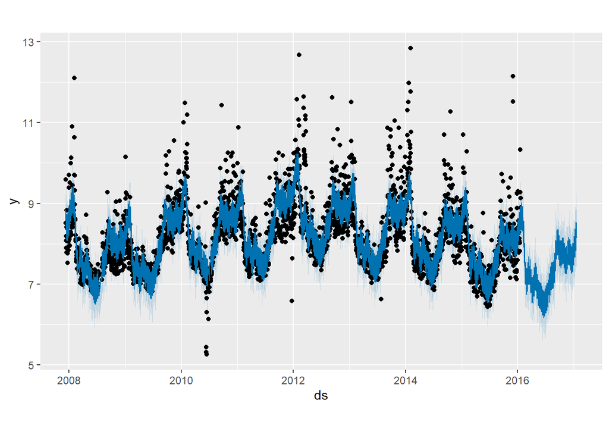

```r
#We then use the generic plot function to plot the forecast, by passing in the model and the forecast dataframe.
plot(prophet_data_frame, forecast)
```

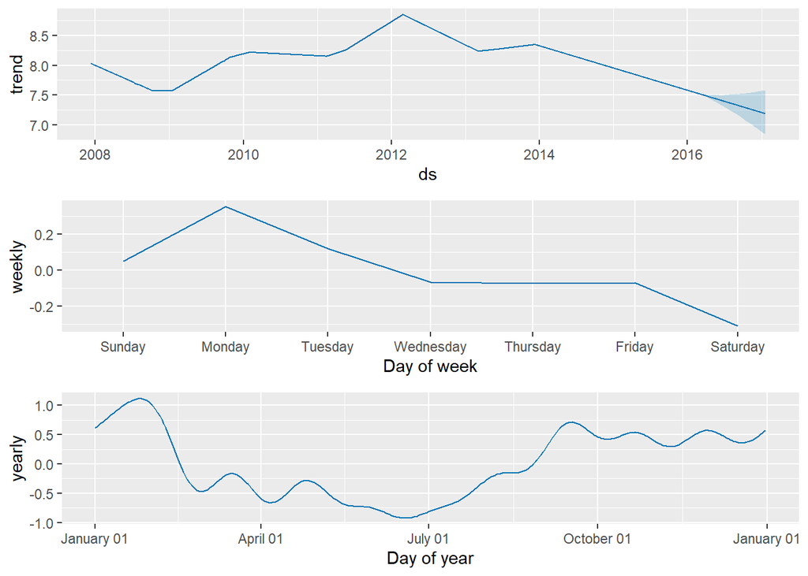

```r
#Finally we use the prophet_plot_components function to see the forecast broken down into trend, weekly seasonality, and yearly seasonality.
prophet_plot_components(prophet_data_frame, forecast)
```

## Conclusion

From our various graphs it is clear that interest in Peyton Manning is and or was seasonal. Firstly from a yearly perspective, our data begins in 2008, this is the year Mr Manning wins his third MVP award.A very impressive achievement, something only 5 other players in NFL history have accomplished.Following this we see a decline in interest into Peyton’s Wikipedia page, most likely due to the end of the season and interest now is upon the draft and future signings. In 2009, interest increases again, this will be because Peyton Manning won his fourth MVP award and reached the Superbowl (XLIV). From 2010 to 2011, surprisingly there is a flat line of interest. If anything, a slight decrease, which is rather outstanding for a player that missed the entire season after a neck surgery. A potential reason for this still steady interest in a player that isn’t active could be the gossip and rumors going around about Manning potentially leaving the Colts. Heading into 2012, we reach a peak interest into Peyton Manning’s Wikipedia page from our trend data. March 20th 2012…Peyton Manning signs with the Denver Broncos. A historic moment, because what took place at the Broncos was absolutely historic. Now, as interest in Peyton Manning’s Wikipedia page peaked in 2012, this now means for the rest of our data until the year 2017, we are in a steady decline. However it is worth noting, in 2013 there is a slight spike in interest, which would be inevitable when Peyton Manning produces a legendary season: 55 touchdown passes (NFL record at the time), 5,477 passing yards (NFL record at the time) & Wins fifth MVP award (most in NFL history). The only way the man could have had the perfect season would have been by winning the Superbowl, of which he got to play in but lost to the Seattle Seahawks. From 2014 onwards, there are no more spikes in interest in Peyton Manning’s Wikipedia page. Just a consistent decline. Peyton Manning is getting older, other players are stealing the limelight of him, most notably Tom Brady. Yet on February 7th 2016, Peyton Manning wins Superbowl 50 with the Broncos against the Carolina Panthers. And our data suggest people didn’t care! How can this be explained? Well, we have to remember the context of our data, it’s interest in Peyton Manning’s Wikipedia page…not google searches. An individual is only inclined to research a person’s Wikipedia page to learn more about them, their life, childhood, education, early career etc. But once Peyton Manning won the Superbowl with the Broncos, he had been in the NFL for just under 18 years, that’s 18 years for fans to research and get to know Peyton’s life story. Which may be enough time.

Next, if we shift our attention onto the weekly data, it is not at all surprising. Interest peaks on a Monday, then trickles down until Saturday where it reaches its lowest point, only to increase again on a Sunday and peak on the Monday. During the regular season in the National Football League, 87.5% of matches are played on a Sunday, therefore depending on how well or not Peyton Manning played on that said Sunday, come Monday morning fans may be interested to know more or remind themselves again of his life & career.

Finally, our last graph, depicting the average interest over the course of a calendar year. This graph is full of peaks and troughs. We begin with the peak for the year, January into February, which is of course playoff season going into the Superbowl. Peyton Manning played in 4 Superbowls, so it was no surprise to still see him playing football come late January. Our data then takes a sharp dive adn ultimately decreases until our lowest point of the year being late June. Although before June, we see two small spikes in interest around early march and late April.This can be accredited to the free agency period (when NFL players can sign for new clubs, like Peyton did from the Colts to the Broncos) which begins in March. And the NFL Draft which tends to be in the last week of April. From July onward we then see a steady and consistent incline for the rest of the calendar year. With regards to peak interest within the second half of the year, this takes place in September. Due to the start of September being when the NFL season begins. As we enter the NFL season, interest in Peyton Manning’s Wikipedia page whilst being nonlinear, is generally consistent, with peaks and troughs only explainable by week to week performances by Manning.